# FInal Project_Code Kaichen Niu

Predicting Credit Card Fraud Using Machine Learning

1)Data Exploration

```python
import numpy as np
import pandas as pd
import seaborn as sns
import plotly.express as px
from matplotlib import pyplot as plt
from sklearn.model_selection import cross_val_score
from sklearn.preprocessing import StandardScaler
from sklearn import metrics
from collections import Counter
from imblearn.over_sampling import SMOTE
from sklearn.feature_selection import VarianceThreshold
from sklearn.model_selection import train_test_split
from sklearn.linear_model import LogisticRegression
import matplotlib.gridspec as gridspec
from sklearn.metrics import confusion_matrix, precision_score, classification_report
from sklearn.neighbors import KNeighborsClassifier
from sklearn.ensemble import RandomForestClassifier
from sklearn.metrics import classification_report
```

```python
df = pd.read_csv("/Users/curry/Desktop/card_fraud_data.csv")
df.head()
```

|  | distance_from_home | distance_from_last_transaction | ratio_to_median_purchase_price | repeat_retailer | used_chip | used_pin_number | online_order | fraud |
| --- | --- | --- | --- | --- | --- | --- | --- | --- |
| 0 | 57.877857 | 0.311140 | 1.945940 | 1 | 1 | 0 | 0 | 0 |
| 1 | 10.829943 | 0.175592 | 1.294219 | 1 | 0 | 0 | 0 | 0 |
| 2 | 5.091079 | 0.805153 | 0.427715 | 1 | 0 | 0 | 1 | 0 |
| 3 | 2.247564 | 5.600044 | 0.362663 | 1 | 1 | 0 | 1 | 0 |
| 4 | 44.190936 | 0.566486 | 2.222767 | 1 | 1 | 0 | 1 | 0 |

```python
df.describe()
```

|  | distance_from_home | distance_from_last_transaction | ratio_to_median_purchase_price | repeat_retailer | used_chip | used_pin_number | online_order | fraud |
| --- | --- | --- | --- | --- | --- | --- | --- | --- |
| count | 5000.000000 | 5000.000000 | 5000.000000 | 5000.000000 | 5000.000000 | 5000.00000 | 5000.000000 | 5000.000000 |
| mean | 27.394794 | 5.126021 | 1.791291 | 0.889400 | 0.340200 | 0.10420 | 0.649200 | 0.087000 |
| std | 64.506072 | 27.092876 | 2.682389 | 0.313668 | 0.473824 | 0.30555 | 0.477268 | 0.281863 |
| min | 0.049270 | 0.001448 | 0.016933 | 0.000000 | 0.000000 | 0.00000 | 0.000000 | 0.000000 |
| 25% | 4.070437 | 0.297886 | 0.495195 | 1.000000 | 0.000000 | 0.00000 | 0.000000 | 0.000000 |
| 50% | 10.394839 | 0.972207 | 0.999346 | 1.000000 | 0.000000 | 0.00000 | 1.000000 | 0.000000 |
| 75% | 26.879761 | 3.272862 | 2.044029 | 1.000000 | 1.000000 | 0.00000 | 1.000000 | 0.000000 |
| max | 2033.498174 | 990.070315 | 65.150879 | 1.000000 | 1.000000 | 1.00000 | 1.000000 | 1.000000 |

```python
df.info()
```

```
<class 'pandas.core.frame.DataFrame'>
RangeIndex: 5000 entries, 0 to 4999
Data columns (total 8 columns):
 #   Column                          Non-Null Count  Dtype
---  ------                          --------------  -----
 0   distance_from_home              5000 non-null   float64
 1   distance_from_last_transaction  5000 non-null   float64
 2   ratio_to_median_purchase_price  5000 non-null   float64
 3   repeat_retailer                 5000 non-null   int64
 4   used_chip                       5000 non-null   int64
 5   used_pin_number                 5000 non-null   int64
 6   online_order                    5000 non-null   int64
 7   fraud                           5000 non-null   int64
dtypes: float64(3), int64(5)
memory usage: 312.6 KB
```

```python
non_frauds_percent = round(df['fraud'].value_counts()[0] / len(df) * 100, 2)
frauds_percent = round(df['fraud'].value_counts()[1] / len(df) * 100, 2)

#percentages
print('Non Frauds:', non_frauds_percent, '% of the dataset')
print('Frauds:', frauds_percent, '% of the dataset')
```

```
Non Frauds: 91.3 % of the dataset
Frauds: 8.7 % of the dataset
```

2）EDA(Explanatory Data Analysis)

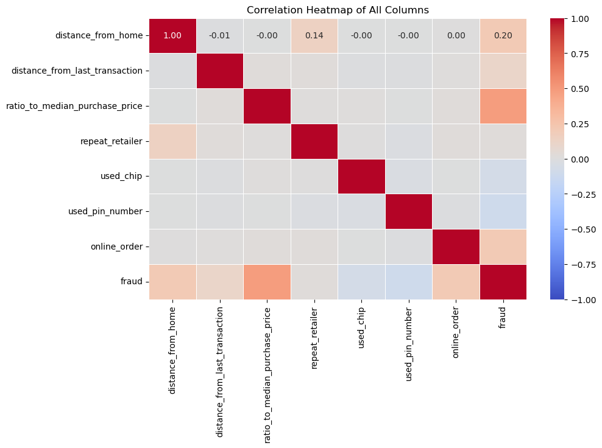

```python
correlation_matrix = df.corr()

# Create a correlation heatmap
plt.figure(figsize=(10, 6))
sns.heatmap(correlation_matrix, annot=True, cmap='coolwarm', fmt=".2f", vmin=-1, vmax=1, center=0, linewidths=0.5)

plt.title('Correlation Heatmap of All Columns')
plt.show()
```

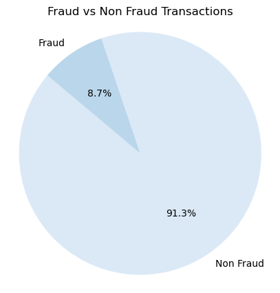

```python
fraud_counts = df['fraud'].value_counts()
fraud_counts.index = fraud_counts.index.map({0: 'Non Fraud', 1: 'Fraud'})
plt.figure(figsize=(5, 5))
plt.pie(fraud_counts, labels=fraud_counts.index, autopct='%1.1f%%', startangle=140, colors=sns.color_palette('Blues'))
plt.title('Fraud vs Non Fraud Transactions')
plt.axis('equal')
plt.show()
```

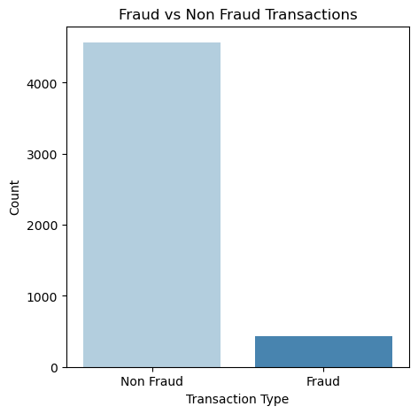

```
Which means this data is imbalanced Dataset
```

```python
fraud_counts = df['fraud'].value_counts()
fraud_counts.index = fraud_counts.index.map({0: 'Non Fraud', 1: 'Fraud'})
plt.figure(figsize=(5, 5))
sns.barplot(x=fraud_counts.index, y=fraud_counts.values, palette='Blues')
plt.title('Fraud vs Non Fraud Transactions')
plt.xlabel('Transaction Type')
plt.ylabel('Count')
plt.show()
print("Which means this data is imbalanced Dataset")
```

Bar Plot of Fraudulent vs. Non-Fraudulent Transactions by Purchased Method. Looking at some visuals to determine moe insights on the data - We see that if the purchase is repeated from the same retailer, buyer did not use a chip, purchase was done online and if the buyer did not use a pin number, it is more likely to be fraudulent.

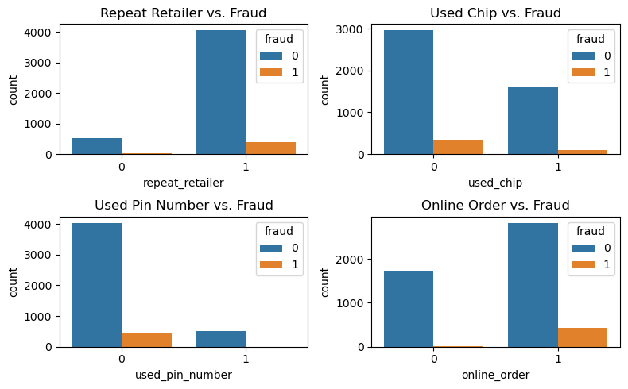

```python
# Create a 2x2 grid of countplots
fig, axes = plt.subplots(2, 2, figsize=(8, 5))

# Plot 1: repeat_retailer vs. fraud
sns.countplot(data=df, x='repeat_retailer', hue='fraud', ax=axes[0, 0])

# Plot 2: used_chip vs. fraud
sns.countplot(data=df, x='used_chip', hue='fraud', ax=axes[0, 1])

# Plot 3: used_pin_number vs. fraud
sns.countplot(data=df, x='used_pin_number', hue='fraud', ax=axes[1, 0])

# Plot 4: online_order vs. fraud
sns.countplot(data=df, x='online_order', hue='fraud', ax=axes[1, 1])

# Set titles for each plot
axes[0, 0].set_title('Repeat Retailer vs. Fraud')
axes[0, 1].set_title('Used Chip vs. Fraud')
axes[1, 0].set_title('Used Pin Number vs. Fraud')
axes[1, 1].set_title('Online Order vs. Fraud')

# Adjust layout
plt.tight_layout()

# Show the plots
plt.show()
```

Looking at rest of the numerical features

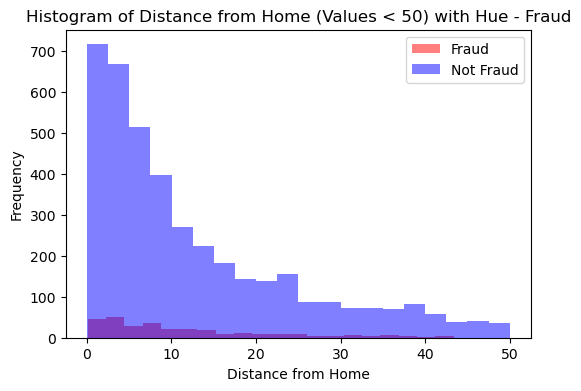

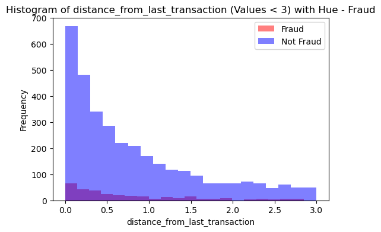

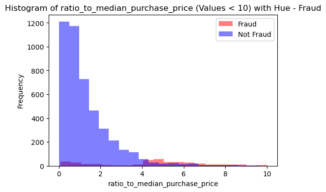

```python
# Filter data by fraud category and values less than 500
fraud_data = df[(df['fraud'] == 1) & (df['distance_from_home'] < 50)]['distance_from_home']
not_fraud_data = df[(df['fraud'] == 0) & (df['distance_from_home'] < 50)]['distance_from_home']

# Create a figure with a specified size
plt.figure(figsize=(6, 4))

# Create a histogram
plt.hist(fraud_data, bins=20, alpha=0.5, color='red', label='Fraud')
plt.hist(not_fraud_data, bins=20, alpha=0.5, color='blue', label='Not Fraud')

plt.xlabel('Distance from Home')
plt.ylabel('Frequency')
plt.title('Histogram of Distance from Home (Values < 50) with Hue - Fraud')
plt.legend()

# Show the histogram
plt.show()

# Filter data by fraud category and values less than 500
fraud_data = df[(df['fraud'] == 1) & (df['distance_from_last_transaction'] < 3)]['distance_from_last_transaction']
not_fraud_data = df[(df['fraud'] == 0) & (df['distance_from_last_transaction'] < 3)]['distance_from_last_transaction']

# Create a figure with a specified size
plt.figure(figsize=(6, 4))

# Create a histogram
plt.hist(fraud_data, bins=20, alpha=0.5, color='red', label='Fraud')
plt.hist(not_fraud_data, bins=20, alpha=0.5, color='blue', label='Not Fraud')

plt.xlabel('distance_from_last_transaction')
plt.ylabel('Frequency')
plt.title('Histogram of distance_from_last_transaction (Values < 3) with Hue - Fraud')
plt.legend()

# Show the histogram
plt.show()


# Filter data by fraud category and values less than 500
fraud_data = df[(df['fraud'] == 1) & (df['ratio_to_median_purchase_price'] < 10)]['ratio_to_median_purchase_price']
not_fraud_data = df[(df['fraud'] == 0) & (df['ratio_to_median_purchase_price'] < 10)]['ratio_to_median_purchase_price']

# Create a figure with a specified size
plt.figure(figsize=(6, 4))

# Create a histogram
plt.hist(fraud_data, bins=20, alpha=0.5, color='red', label='Fraud')
plt.hist(not_fraud_data, bins=20, alpha=0.5, color='blue', label='Not Fraud')

plt.xlabel('ratio_to_median_purchase_price')
plt.ylabel('Frequency')
plt.title('Histogram of ratio_to_median_purchase_price (Values < 10) with Hue - Fraud')
plt.legend()

# Show the histogram
plt.show()
```

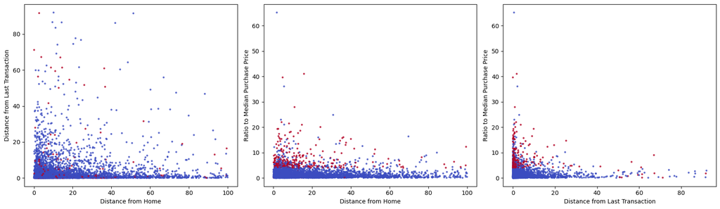

```python
# Filter data to include only values less than 30 for all three columns
filtered_data = df[(df['distance_from_home'] < 100) & (df['distance_from_last_transaction'] < 100) & (df['ratio_to_median_purchase_price'] < 100)]

# Create a 1x3 grid of scatterplots
fig, axes = plt.subplots(1, 3, figsize=(17, 5))

# Scatterplot 1: distance_from_home vs. distance_from_last_transaction
axes[0].scatter(filtered_data['distance_from_home'], filtered_data['distance_from_last_transaction'], c=filtered_data['fraud'], cmap='coolwarm', alpha=0.7, s=5)
axes[0].set_xlabel('Distance from Home')
axes[0].set_ylabel('Distance from Last Transaction')
#axes[0].set_title('Distance from Home vs. Distance from Last Transaction')

# Scatterplot 2: distance_from_home vs. ratio_to_median_purchase_price
axes[1].scatter(filtered_data['distance_from_home'], filtered_data['ratio_to_median_purchase_price'], c=filtered_data['fraud'], cmap='coolwarm', alpha=0.7, s=5)
axes[1].set_xlabel('Distance from Home')
axes[1].set_ylabel('Ratio to Median Purchase Price')
#axes[1].set_title('Distance from Home vs. Ratio to Median Purchase Price')

# Scatterplot 3: distance_from_last_transaction vs. ratio_to_median_purchase_price
axes[2].scatter(filtered_data['distance_from_last_transaction'], filtered_data['ratio_to_median_purchase_price'], c=filtered_data['fraud'], cmap='coolwarm', alpha=0.7, s=5)
axes[2].set_xlabel('Distance from Last Transaction')
axes[2].set_ylabel('Ratio to Median Purchase Price')
#axes[2].set_title('Distance from Last Transaction vs. Ratio to Median Purchase Price')

# Adjust layout
plt.tight_layout()

# Show the scatterplots
plt.show()
```

3. Data Pre-processing

Check duplicated values

```python
duplicate_count = df.duplicated().sum()
print("Count of duplicate rows:", duplicate_count)
```

```
Count of duplicate rows: 0
```

Checking for outliers

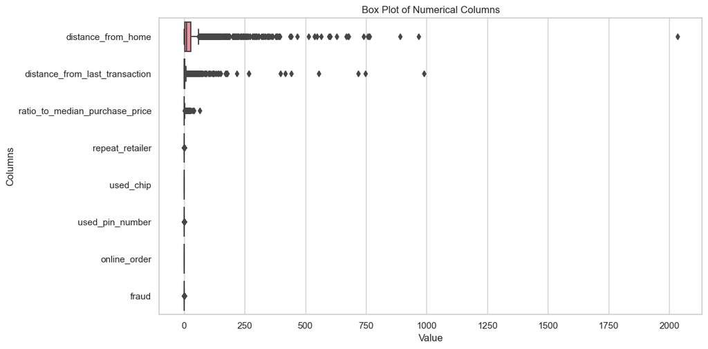

```python
df = df.copy()

# Selecting numerical columns to plot
numerical_columns = df.select_dtypes(include=['float64', 'int64']).columns
sns.set(style="whitegrid", palette="Blues_r")
plt.figure(figsize=(12, 6))
sns.boxplot(data=df[numerical_columns], orient="h")
plt.title('Box Plot of Numerical Columns')
plt.xlabel('Value')
plt.ylabel('Columns')
plt.tight_layout()

plt.show()
```

Detecting outliers using the IQR method

```python
def IQR_method(df, n, features):
    outlier_list = []

    for column in features:
        # 1st quartile (25%)
        Q1 = np.percentile(df[column], 25)
        # 3rd quartile (75%)
        Q3 = np.percentile(df[column], 75)
        # Interquartile range (IQR)
        IQR = Q3 - Q1
        # Outlier step
        outlier_step = 1.5 * IQR
        # Determining a list of indices of outliers
        outlier_list_column = df[(df[column] < Q1 - outlier_step) | (df[column] > Q3 + outlier_step)].index
        # Appending the list of outliers
        outlier_list.extend(outlier_list_column)

    outlier_list = Counter(outlier_list)
    multiple_outliers = [k for k, v in outlier_list.items() if v > n ]

    print('Total number of deleted outliers:', len(multiple_outliers))

    return multiple_outliers

Outliers_IQR = IQR_method(df, 1, numerical_columns)
```

```
Total number of deleted outliers: 717
```

```python
df_out = df.drop(Outliers_IQR, axis=0).reset_index(drop=True)
print('Total number after deleted outliers:', len(df_out))
```

```
Total number after deleted outliers: 4283
```

4）Model method---4.1 Split the data

```python
# Assuming 'fraud' is your target variable
X = df_out.drop('fraud', axis=1)
y = df_out['fraud']

from sklearn.model_selection import train_test_split

# Performing stratified split with a test size of 30% and a random state of 42
X_train, X_test, y_train, y_test = train_test_split(X, y, stratify=y, test_size=0.3, random_state=42)

print("Train set:")
print("Total rows:", len(X_train))
print("Frauds:", y_train.sum())
print("Non Frauds:", (y_train == 0).sum())

print("\nTest set:")
print("Total rows:", len(X_test))
print("Frauds:", y_test.sum())
print("Non Frauds:", (y_test == 0).sum())
```

```
Train set:
Total rows: 2998
Frauds: 21
Non Frauds: 2977

Test set:
Total rows: 1285
Frauds: 9
Non Frauds: 1276
```

4.2 Feature Scaling

-Standardization (or scaling) is a preprocessing step that transforms data to have a mean of 0 and a standard deviation of 1 This ensures that all features contribute equally to the model training proces.

-It's important to scale features when their scales differ widely or when using algorithms that are sensitive to feature scales (e.g., SVMs, KNN).

```python
from sklearn.preprocessing import StandardScaler

# Function for scaling specific columns in a DataFrame
def Standard_Scaler(df, col_names):
    scaler = StandardScaler()
    df_scaled = df.copy()  # Create a copy of the DataFrame to avoid modifying the original
    df_scaled[col_names] = scaler.fit_transform(df_scaled[col_names])

    return df_scaled

# Example usage:
col_names= ['distance_from_home', 'distance_from_last_transaction',
                      'ratio_to_median_purchase_price', 'repeat_retailer',
                      'used_chip', 'used_pin_number', 'online_order']

# Apply StandardScaler to X_train and X_test
X_train = Standard_Scaler(X_train, col_names)
X_test = Standard_Scaler(X_test, col_names)

# Print to verify
print("X_train (scaled):")
print(X_train.head())

print("\nX_test (scaled):")
print(X_test.head())
```

```
X_train (scaled):
      distance_from_home  distance_from_last_transaction  \
3442           -0.186684                        2.445384
1823           -0.445165                       -0.217428
3985            0.815049                       -0.245598
1294            0.297540                        0.381414
4266           -0.060957                       -0.218226

      ratio_to_median_purchase_price  repeat_retailer  used_chip  \
3442                       -0.115035         0.312033  -0.735252
1823                       -0.256722         0.312033  -0.735252
3985                        0.110919         0.312033  -0.735252
1294                       -0.495526         0.312033  -0.735252
4266                        0.822982         0.312033   1.360077

      used_pin_number  online_order
3442        -0.285534      0.785522
1823        -0.285534      0.785522
3985        -0.285534      0.785522
1294        -0.285534      0.785522
4266        -0.285534      0.785522

X_test (scaled):
      distance_from_home  distance_from_last_transaction  \
3062           -0.204929                       -0.140525
1814           -0.453762                       -0.132256
2980           -0.210272                       -0.121012
1637           -0.336232                       -0.076899
3369           -0.466338                       -0.082255

      ratio_to_median_purchase_price  repeat_retailer  used_chip  \
3062                       -0.763253         0.328266  -0.727847
1814                        0.232645        -3.046309   1.373914
2980                        1.473973         0.328266   1.373914
1637                        0.774087         0.328266   1.373914
3369                       -0.652564        -3.046309   1.373914

      used_pin_number  online_order
3062        -0.292069     -1.321259
1814        -0.292069      0.756854
2980        -0.292069      0.756854
1637        -0.292069      0.756854
3369        -0.292069      0.756854
```

4.3 Resampling Using SMOTE

```python
from imblearn.over_sampling import SMOTE
# Initialize SMOTE
smote = SMOTE(random_state=42)

# Perform SMOTE oversampling
X_train_resampled, y_train_resampled = smote.fit_resample(X_train, y_train)

# Check the class distribution before and after oversampling
print("Before Oversampling:", Counter(y_train))
print("After Oversampling:", Counter(y_train_resampled))
```

```
Before Oversampling: Counter({0: 2977, 1: 21})
After Oversampling: Counter({0: 2977, 1: 2977})
```

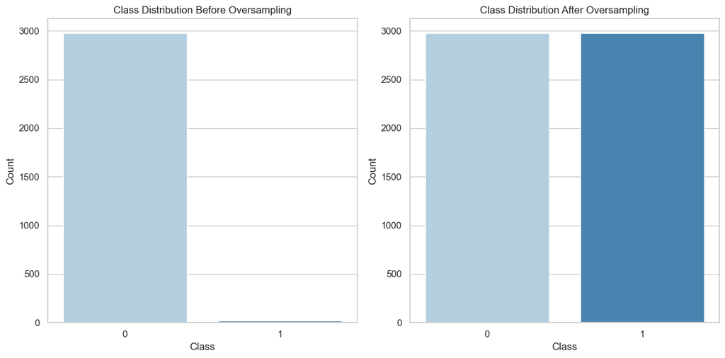

```python
before_counts = Counter(y_train)
after_counts = Counter(y_train_resampled)

plt.figure(figsize=(12, 6))
plt.subplot(1, 2, 1)
sns.countplot(x=y_train, palette='Blues')
plt.title('Class Distribution Before Oversampling')
plt.xlabel('Class')
plt.ylabel('Count')

plt.subplot(1, 2, 2)
sns.countplot(x=y_train_resampled, palette='Blues')
plt.title('Class Distribution After Oversampling')
plt.xlabel('Class')
plt.ylabel('Count')

plt.tight_layout()
plt.show()
```

5. Machine Learning Algorithm

5.1. K-Nearest Neighbors (KNN) algorithm

```python
from sklearn.neighbors import KNeighborsClassifier

# Initialize KNN classifier with k=3
knn = KNeighborsClassifier(n_neighbors=3)

# Train the model on oversampled data
knn.fit(X_train_resampled, y_train_resampled)

y_pred = knn.predict(X_test)

accuracy = knn.score(X_test, y_test)
print("\nKNN Accuracy:", accuracy*100)
```

```
KNN Accuracy: 98.98832684824903
```

```
Confusion Matrix:
[[1263   13]
 [   0    9]]

Precision Score: 0.4090909090909091
```

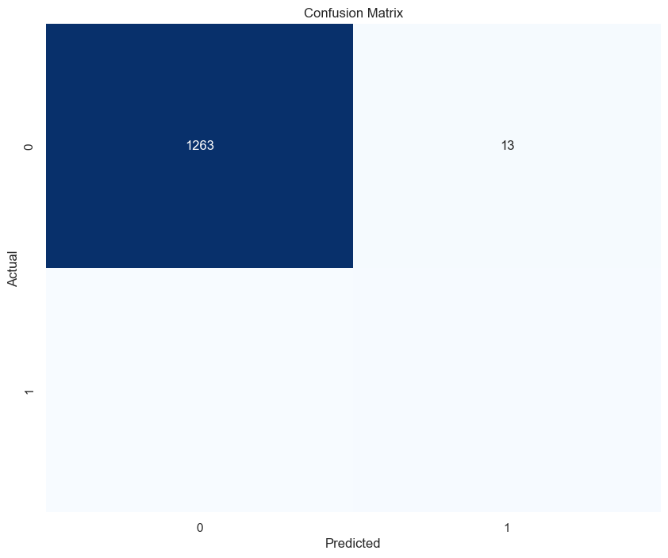

```
Classification Report for KNN:
              precision    recall  f1-score   support

           0       1.00      0.99      0.99      1276
           1       0.41      1.00      0.58         9

    accuracy                           0.99      1285
   macro avg       0.70      0.99      0.79      1285
weighted avg       1.00      0.99      0.99      1285
```

```python
from sklearn.metrics import confusion_matrix, precision_score, classification_report
cm = confusion_matrix(y_test, y_pred)
print("Confusion Matrix:")
print(cm)

# Calculate precision score
precision = precision_score(y_test, y_pred)
print("\nPrecision Score:", precision)

# Plot confusion matrix with light blue palette
plt.figure(figsize=(10, 8))
sns.heatmap(cm, annot=True, cmap="Blues", fmt='g', cbar=False)
plt.xlabel('Predicted')
plt.ylabel('Actual')
plt.title('Confusion Matrix')
plt.show()

# Display classification report
print("\nClassification Report for KNN:")
print(classification_report(y_test, y_pred))
```

5.2. Logistic Regression

```python
from sklearn.linear_model import LogisticRegression

log_reg = LogisticRegression(random_state=42, solver='liblinear', max_iter=1000)

# Train the model on scaled oversampled data
log_reg.fit(X_train, y_train)

# Predict on test set
y_pred = log_reg.predict(X_test)

# Calculate accuracy
accuracy = log_reg.score(X_test, y_test)
print("\nLogistic Regression Accuracy:", accuracy * 100)
```

```
Logistic Regression Accuracy: 99.29961089494164
```

```
Standard Logistic Regression Accuracy: 99.29961089494164

Logistic Regression with Class Weights Accuracy: 95.71984435797665

Confusion Matrix with Class Weights:
[[1221   55]
 [   0    9]]

Precision Score with Class Weights: 0.140625

Classification Report with Class Weights:
              precision    recall  f1-score   support

           0       1.00      0.96      0.98      1276
           1       0.14      1.00      0.25         9

    accuracy                           0.96      1285
   macro avg       0.57      0.98      0.61      1285
weighted avg       0.99      0.96      0.97      1285
```

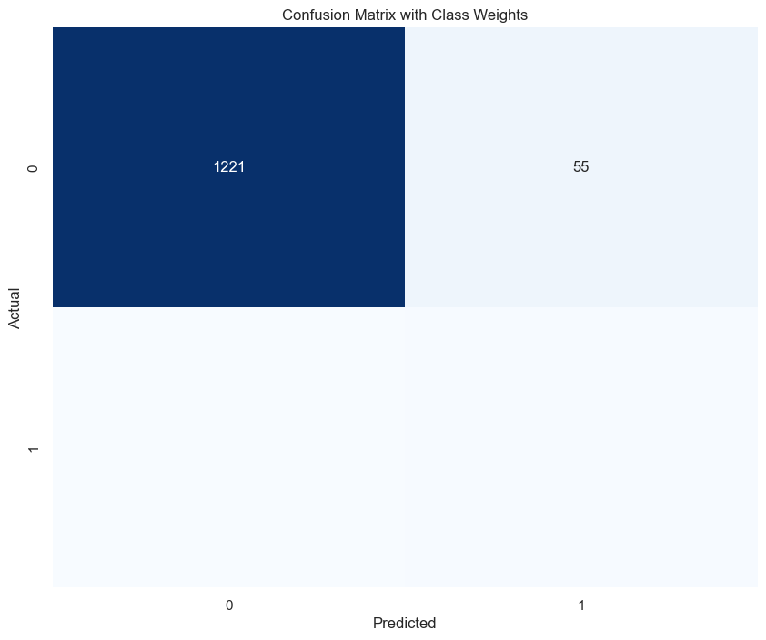

```python
log_reg = LogisticRegression(random_state=42, solver='liblinear', max_iter=1000)
log_reg.fit(X_train, y_train)
y_pred = log_reg.predict(X_test)
accuracy = log_reg.score(X_test, y_test)
print("\nStandard Logistic Regression Accuracy:", accuracy * 100)

# Training the Logistic Regression model with class weights
log_reg_weighted = LogisticRegression(random_state=42, solver='liblinear', max_iter=1000, class_weight='balanced')
log_reg_weighted.fit(X_train, y_train)
y_pred_weighted = log_reg_weighted.predict(X_test)
accuracy_weighted = log_reg_weighted.score(X_test, y_test)
print("\nLogistic Regression with Class Weights Accuracy:", accuracy_weighted * 100)

# Evaluating and displaying results for the weighted model
cm_weighted = confusion_matrix(y_test, y_pred_weighted)
precision_weighted = precision_score(y_test, y_pred_weighted, zero_division=1)
print("\nConfusion Matrix with Class Weights:")
print(cm_weighted)
print("\nPrecision Score with Class Weights:", precision_weighted)
print("\nClassification Report with Class Weights:")
print(classification_report(y_test, y_pred_weighted))

# Plotting the confusion matrix for the weighted model
plt.figure(figsize=(10, 8))
sns.heatmap(cm_weighted, annot=True, cmap="Blues", fmt='g', cbar=False)
plt.xlabel('Predicted')
plt.ylabel('Actual')
plt.title('Confusion Matrix with Class Weights')
plt.show()
```

5.3 Random Forest

```python
from sklearn.ensemble import RandomForestClassifier

# Initialize Random Forest classifier
rf = RandomForestClassifier(n_estimators=100, random_state=13)

# Train the model on oversampled data
rf.fit(X_train, y_train)

# Predict on test set
y_pred = rf.predict(X_test)

# Calculate accuracy
accuracy = rf.score(X_test, y_test)
print("\nRandom Forest Accuracy:", accuracy*100)
```

```
Random Forest Accuracy: 99.22178988326849
```

```
Confusion Matrix:
[[1268    8]
 [   2    7]]

Precision Score: 0.4666666666666667
```

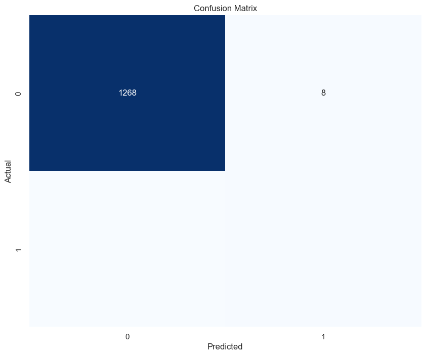

```
Classification Report for random forest:
              precision    recall  f1-score   support

           0       1.00      0.99      1.00      1276
           1       0.47      0.78      0.58         9

    accuracy                           0.99      1285
   macro avg       0.73      0.89      0.79      1285
weighted avg       0.99      0.99      0.99      1285
```

```python
# Calculate confusion matrix
cm = confusion_matrix(y_test, y_pred)
print("Confusion Matrix:")
print(cm)

# Calculate precision score
precision = precision_score(y_test, y_pred)
print("\nPrecision Score:", precision)

# Plot confusion matrix
plt.figure(figsize=(10, 8))
sns.heatmap(cm, annot=True, cmap="Blues", fmt='g', cbar=False)
plt.xlabel('Predicted')
plt.ylabel('Actual')
plt.title('Confusion Matrix')
plt.show()

# Display classification report
print("\nClassification Report for random forest:")
print(classification_report(y_test, y_pred))
```

6. Conclusion

Cross-Validation Error/Accuracy

```python
from sklearn.model_selection import cross_val_score

# Cross-validation for KNN
knn_cv_scores = cross_val_score(knn, X_train_resampled, y_train_resampled, cv=5)
print(f"KNN Cross-validation Scores: {knn_cv_scores}")
print(f"KNN Cross-validation Accuracy: {knn_cv_scores.mean() * 100:.2f}% ± {knn_cv_scores.std() * 100:.2f}")

# Cross-validation for Logistic Regression
log_reg_cv_scores = cross_val_score(log_reg, X_train, y_train, cv=5)
print(f"Logistic Regression Cross-validation Scores: {log_reg_cv_scores}")
print(f"Logistic Regression Cross-validation Accuracy: {log_reg_cv_scores.mean() * 100:.2f}% ± {log_reg_cv_scores.std() * 100:.2f}")
```

```
KNN Cross-validation Scores: [0.99916037 0.99832074 0.99832074 0.99832074 1.        ]
KNN Cross-validation Accuracy: 99.88% ± 0.07
Logistic Regression Cross-validation Scores: [0.99333333 0.99333333 0.99       0.9933222  0.9933222 ]
Logistic Regression Cross-validation Accuracy: 99.27% ± 0.13
```

Training Error/Accuracy

```python
try:
    # This will fail if 'log_reg' is not fitted
    log_reg_train_accuracy = log_reg.score(X_train, y_train)
    print(f"Logistic Regression Training Accuracy: {log_reg_train_accuracy * 100:.2f}%")
except:
    # Define and fit the Logistic Regression model if not already done
    log_reg = LogisticRegression(random_state=42, solver='liblinear', max_iter=1000)
    log_reg.fit(X_train, y_train)  # Fit the model
    log_reg_train_accuracy = log_reg.score(X_train, y_train)  # Now score it
    print(f"Logistic Regression Training Accuracy: {log_reg_train_accuracy * 100:.2f}%")
```

```
Logistic Regression Training Accuracy: 99.27%
```

```python
from sklearn.ensemble import RandomForestClassifier
from sklearn.model_selection import cross_val_score

# Initialize Random Forest classifier
rf = RandomForestClassifier(n_estimators=100, random_state=42)

# Train the model on the training data
rf.fit(X_train, y_train)

# Training accuracy
rf_train_accuracy = rf.score(X_train, y_train)
print(f"Random Forest Training Accuracy: {rf_train_accuracy * 100:.2f}%")

# Test accuracy
rf_test_accuracy = rf.score(X_test, y_test)
print(f"Random Forest Test Accuracy: {rf_test_accuracy * 100:.2f}%")

# Cross-validation accuracy
rf_cv_scores = cross_val_score(rf, X_train, y_train, cv=5)
print(f"Random Forest Cross-validation Scores: {rf_cv_scores}")
print(f"Random Forest Cross-validation Accuracy: {rf_cv_scores.mean() * 100:.2f}% ± {rf_cv_scores.std() * 100:.2f}")

# Optionally, display the classification report
from sklearn.metrics import classification_report
y_pred_rf = rf.predict(X_test)
print("\nClassification Report for Random Forest:")
print(classification_report(y_test, y_pred_rf))
```

```
Random Forest Training Accuracy: 100.00%
Random Forest Test Accuracy: 99.14%
Random Forest Cross-validation Scores: [0.995      0.99833333 0.99833333 1.         0.99833055]
Random Forest Cross-validation Accuracy: 99.80% ± 0.16

Classification Report for Random Forest:
              precision    recall  f1-score   support

           0       1.00      0.99      1.00      1276
           1       0.44      0.78      0.56         9

    accuracy                           0.99      1285
   macro avg       0.72      0.89      0.78      1285
weighted avg       0.99      0.99      0.99      1285
```

```python
# Initialize models with hypothetical parameters
knn = KNeighborsClassifier(n_neighbors=3)
log_reg = LogisticRegression(random_state=42, solver='liblinear', max_iter=1000)
rf = RandomForestClassifier(n_estimators=100, random_state=42)

# Fit models
knn.fit(X_train_resampled, y_train_resampled)  # Fitting KNN on resampled data for handling class imbalance
log_reg.fit(X_train, y_train)  # Fitting Logistic Regression on original training data
rf.fit(X_train, y_train)  # Fitting Random Forest on original training data

# Calculate training and test accuracies
knn_train_accuracy = knn.score(X_train_resampled, y_train_resampled)
knn_test_accuracy = knn.score(X_test, y_test)
log_reg_train_accuracy = log_reg.score(X_train, y_train)
log_reg_test_accuracy = log_reg.score(X_test, y_test)
rf_train_accuracy = rf.score(X_train, y_train)
rf_test_accuracy = rf.score(X_test, y_test)

# Perform cross-validation and compute mean and std deviation
knn_cv_scores = cross_val_score(knn, X_train_resampled, y_train_resampled, cv=5)
log_reg_cv_scores = cross_val_score(log_reg, X_train, y_train, cv=5)
rf_cv_scores = cross_val_score(rf, X_train, y_train, cv=5)

# Compile results into a DataFrame
results_data = {
    "Model": ["KNN", "Logistic Regression", "Random Forest"],
    "Training Accuracy": [knn_train_accuracy * 100, log_reg_train_accuracy * 100, rf_train_accuracy * 100],
    "Test Accuracy": [knn_test_accuracy * 100, log_reg_test_accuracy * 100, rf_test_accuracy * 100],
    "Cross-validation Accuracy Mean": [knn_cv_scores.mean() * 100, log_reg_cv_scores.mean() * 100, rf_cv_scores.mean() * 100],
    "Cross-validation Accuracy Std Dev": [knn_cv_scores.std() * 100, log_reg_cv_scores.std() * 100, rf_cv_scores.std() * 100]
}

results_df = pd.DataFrame(results_data)
results_df.set_index("Model", inplace=True)

# Print the DataFrame
print(results_df)

# Print classification reports for each model
print("\nClassification Report for KNN:")
print(classification_report(y_test, knn.predict(X_test)))
print("\nClassification Report for Logistic Regression:")
print(classification_report(y_test, log_reg.predict(X_test)))
print("\nClassification Report for Random Forest:")
print(classification_report(y_test, rf.predict(X_test)))
```

```
                     Training Accuracy  Test Accuracy  \
Model
KNN                          99.899227      98.988327
Logistic Regression          99.266177      99.299611
Random Forest               100.000000      99.143969

                     Cross-validation Accuracy Mean  \
Model
KNN                                       99.882452
Logistic Regression                       99.266221
Random Forest                             99.799944

                     Cross-validation Accuracy Std Dev
Model
KNN                                           0.067170
Logistic Regression                           0.133112
Random Forest                                 0.163288

Classification Report for KNN:
              precision    recall  f1-score   support

           0       1.00      0.99      0.99      1276
           1       0.41      1.00      0.58         9

    accuracy                           0.99      1285
   macro avg       0.70      0.99      0.79      1285
weighted avg       1.00      0.99      0.99      1285


Classification Report for Logistic Regression:
              precision    recall  f1-score   support

           0       0.99      1.00      1.00      1276
           1       0.00      0.00      0.00         9

    accuracy                           0.99      1285
   macro avg       0.50      0.50      0.50      1285
weighted avg       0.99      0.99      0.99      1285


Classification Report for Random Forest:
              precision    recall  f1-score   support

           0       1.00      0.99      1.00      1276
           1       0.44      0.78      0.56         9

    accuracy                           0.99      1285
   macro avg       0.72      0.89      0.78      1285
weighted avg       0.99      0.99      0.99      1285
```